# 빅데이터 시각화

### 01. R 기초

##### 01.1.3 R 들어가기

```r
## 단순 계산기 기능
(20+3*2)/3
```

```
## [1] 8.666667
```

```r
# 디폴트로 소수점 7자리에서 반올림
# 자릿수 변환
options(digits=4)
(20+3*2)/3
```

```
## [1] 8.667
```

```r
## 수열(sequence)의 생성
1:10
```

```
##  [1]  1  2  3  4  5  6  7  8  9 10
```

```r
seq(1,5,0.5)
```

```
## [1] 1.0 1.5 2.0 2.5 3.0 3.5 4.0 4.5 5.0
```

```r
# 반복되는 원소(repeat elements)의 수열
rep(10,5)
```

```
## [1] 10 10 10 10 10
```

```r
rep(1:5,2)
```

```
##  [1] 1 2 3 4 5 1 2 3 4 5
```

```r
## 연속되는 알파벳 생성
LETTERS[1:10]
```

```
##  [1] "A" "B" "C" "D" "E" "F" "G" "H" "I" "J"
```

```r
letters[-(3:5)]
```

```
##  [1] "a" "b" "f" "g" "h" "i" "j" "k" "l" "m" "n" "o" "p" "q" "r" "s" "t" "u" "v"
## [20] "w" "x" "y" "z"
```

```r
## LETTERS, letters 와 함께 R에 내장된 상수 : month.name, month.abb, state.name, state.abb, pi 등이 있음.

month.name
```

```
##  [1] "January"   "February"  "March"     "April"     "May"       "June"
##  [7] "July"      "August"    "September" "October"   "November"  "December"
```

```r
month.abb
```

```
##  [1] "Jan" "Feb" "Mar" "Apr" "May" "Jun" "Jul" "Aug" "Sep" "Oct" "Nov" "Dec"
```

```r
### abbreviate(month.name)의 결과와 비교해 볼 것
abbreviate(month.name)
```

```
##   January  February     March     April       May      June      July    August
##    "Jnry"    "Fbrr"    "Mrch"    "Aprl"     "May"    "June"    "July"    "Agst"
## September   October  November  December
##    "Sptm"    "Octb"    "Nvmb"    "Dcmb"
```

```r
pi
```

```
## [1] 3.142
```

```r
## 값(value)을 변수에 할당
x <- 3*4
x
```

```
## [1] 12
```

##### 01.2.1 help() 함수 이용하기

```r
## 함수에 대한 도움말
#help(summary)  # ?summary와 동일

## 키워드에 대한 도움말
#help("for")  # ?"for"와 동일

## help.search() 함수
## 키워드를 통해 관련 자료를 내 컴퓨터에 설치된(installed) 패키지에서 찾음.
## 키워드와 관련된 패키지와 함수 정보 제공
#??ANOVA  # help.search("ANOVA")와 동일

## apropos() 함수
## 로딩된(loaede) 패키지에서 키워드를 포함하는 객체를 찾음
#apropos("ANOVA")

## help.start() 함수
## HTML 웹 브라우저를 통한 도움말을 제공
#help.start()
```

##### 01.2.2 R의 자료 검색

```r
## R 환경 내에서 키워드를 이용한 사이트 또는 함수 찾기
#RSiteSearch("keywords")
```

### 01.3 주요 연산자 및 R 객체

##### 01.3.1 주요 연산자 및 기호

[output not shown]

- R 객체명은 대, 소문자를 구분한다.
- R 프로그램의 각 행에서 # 기호 이후의 모든 내요은 주석문(comments)으로 취급되며, 따라서 프로그램의 수행에는 영향을 주지 않는다.

### 01.3.2 주요 객체와 생성

R객체는 모드(mode)를 통해 특징지어진다.  
모드의 종류는 다음과 같다.  
- 빈 객체(null or empty object)  
- 논리형(logical) : TRUE 또는 FALSE  
- 수치형(numeric) : 5, 3.1415, 10+sqrt(3)  
- 복소수형(complex) : 5-3i, complex(2,5,-2)  
- 문자형(character) : “Red”, “John”, “y=a+bx”

class() : 객체의 모드 확인  
str() : 객체의 구조 확인

##### (a) 벡터 객체 생성

```r
## 벡터(vector) 객체 생성 : c() 함수 사용 (c : combine)
v <- c( 2, 4, 6)
v  # 숫자형 벡터
```

```
## [1] 2 4 6
```

```r
class(v)
```

```
## [1] "numeric"
```

```r
str(v)
```

```
##  num [1:3] 2 4 6
```

```r
## 이름을 가진 벡터(named vector) 생성
names(v) <- c("site1","site2","site3")

v  #(이름을 가진) 숫자형 벡터
```

```
## site1 site2 site3
##     2     4     6
```

```r
class(v)
```

```
## [1] "numeric"
```

```r
v[1]
```

```
## site1
##     2
```

```r
v["site1"]
```

```
## site1
##     2
```

```r
v[2] <- "Kim"
v  # (이름을 가진) 문자형 벡터
```

```
## site1 site2 site3
##   "2" "Kim"   "6"
```

```r
class(v)
```

```
## [1] "character"
```

```r
(v1 <- c(v[1],v[3]))
```

```
## site1 site3
##   "2"   "6"
```

##### (b) 요인 객체 생성

요인(factor)은 범주형 자료를 다룰 때 사용되며, 취할 수 있는 가능한 값을 수준(levels)으로 가진다.

```r
## factor() 함수 : 요인 객체 생성
f <- factor(c("low","high"))
f
```

```
## [1] low  high
## Levels: high low
```

```r
## gl() 함수 : 요인 수열(factor sequence)의 생성
f.1 <- gl(2, 3, labels=c("male","female"))
f.1
```

```
## [1] male   male   male   female female female
## Levels: male female
```

```r
## table() 함수 : 요인 객체에 대해 빈도표(frequece table) 작성
table(f.1)
```

```
## f.1
##   male female
##      3      3
```

```r
f.2 <- factor(c("white","black","white","white","black","white"))
(t <- table(f.1, f.2))
```

```
##         f.2
## f.1      black white
##   male       1     2
##   female     1     2
```

```r
## margin.table() 함수 : 주변표 작성
margin.table(t,1)
```

```
## f.1
##   male female
##      3      3
```

```r
margin.table(t,2)
```

```
## f.2
## black white
##     2     4
```

```r
## prop.table() 함수 : 비율표 작성
prop.table(t,1)
```

```
##         f.2
## f.1       black  white
##   male   0.3333 0.6667
##   female 0.3333 0.6667
```

```r
prop.table(t,2)
```

```
##         f.2
## f.1      black white
##   male     0.5   0.5
##   female   0.5   0.5
```

```r
prop.table(t)
```

```
##         f.2
## f.1       black  white
##   male   0.1667 0.3333
##   female 0.1667 0.3333
```

##### (c) 행렬과 배열 객체 작성

```r
## matrix() 함수 : 행렬(matrix) 객체 생성
m <- matrix(c(1,2,3,4,5,6,7,8),2,4)
m
```

```
##      [,1] [,2] [,3] [,4]
## [1,]    1    3    5    7
## [2,]    2    4    6    8
```

```r
m[2,2]
```

```
## [1] 4
```

```r
m[1,]
```

```
## [1] 1 3 5 7
```

```r
m[1,-3]
```

```
## [1] 1 3 7
```

```r
## array() 함수 : 배열(array) 객체 생성
a <- array(1:30, dim=c(2,5,3))
a
```

```
## , , 1
##
##      [,1] [,2] [,3] [,4] [,5]
## [1,]    1    3    5    7    9
## [2,]    2    4    6    8   10
##
## , , 2
##
##      [,1] [,2] [,3] [,4] [,5]
## [1,]   11   13   15   17   19
## [2,]   12   14   16   18   20
##
## , , 3
##
##      [,1] [,2] [,3] [,4] [,5]
## [1,]   21   23   25   27   29
## [2,]   22   24   26   28   30
```

##### (d) 리스트 객체 생성

리스트(list)는 서로 다른 유형의 객체(objects)들의 순서화된 모임(ordered collection)이다.

```r
## list() 함수 : 리스트 객체 생성
l <- list(id=c(1,2,3), name=c("Kim","Lee","Park"), score=c(70, 80, 90))
l
```

```
## $id
## [1] 1 2 3
##
## $name
## [1] "Kim"  "Lee"  "Park"
##
## $score
## [1] 70 80 90
```

```r
l[3]  # (**유의**) 원소가 하나인 리스트
```

```
## $score
## [1] 70 80 90
```

```r
l[[3]]  # (**유의**) 리스트가 아닌 벡터 객체임에 유의
```

```
## [1] 70 80 90
```

```r
l$score  # l[[3]]과 동일
```

```
## [1] 70 80 90
```

```r
unlist(l)  # 이름을 가지는 문자형 벡터 객체
```

```
##    id1    id2    id3  name1  name2  name3 score1 score2 score3
##    "1"    "2"    "3"  "Kim"  "Lee" "Park"   "70"   "80"   "90"
```

##### (e) 데이터프레임 객체 생성

데이터프레임(data frame)은 행렬과 유사하나 column 별로 이름이 부여되어 있으며, 행렬과는 달리 각 column별로 서로 다른 형태의 자료를 가질 수 있다는 면에서 리스트와 유사하다.

```r
## data.frame() 함수 : 데이터프레임 객체 생성
d <- data.frame(id=c(1,2,3), name=c("Kim","Lee","Park"), score=c(70, 80, 90))
d
```

```
##   id name score
## 1  1  Kim    70
## 2  2  Lee    80
## 3  3 Park    90
```

```r
d$naem
```

[output not shown]

```r
d$score
```

```
## [1] 70 80 90
```

```r
d[2,3]
```

```
## [1] 80
```

```r
d[1,]
```

```
##   id name score
## 1  1  Kim    70
```

```r
d[,1]
```

```
## [1] 1 2 3
```

```r
d[d$score >=80, ]
```

```
##   id name score
## 2  2  Lee    80
## 3  3 Park    90
```

```r
d[d$name=="Kim", ]
```

```
##   id name score
## 1  1  Kim    70
```

```r
d[d$name=="Kim", "score"]
```

```
## [1] 70
```

```r
d[d$name=="Kim",c("id","score")]
```

```
##   id score
## 1  1    70
```

```r
names(d)
```

```
## [1] "id"    "name"  "score"
```

```r
names(d)[3] <- "total"
d
```

```
##   id name total
## 1  1  Kim    70
## 2  2  Lee    80
## 3  3 Park    90
```

##### (f) 테이블 객체 생성

```r
## 테이블(table) 객체 생성 : table() 함수를 이용
table(rpois(100, 5))
```

```
##
##  1  2  3  4  5  6  7  8  9 10
##  2 10 16 17 17 13 13  6  4  2
```

```r
# rpois(100, 5) : 평균이 5인 포아송분포로 부터 100개의 난수를 발생

## 2차원 테이블 객체 생성
table(rbinom(100, 10, 0.5), rbinom(100, 10, .2)) # 길이가 같아야함
```

```
##
##      0  1  2  3  4  5  6
##   2  0  2  0  1  0  1  0
##   3  2  4  3  2  0  0  1
##   4  3  9 12  3  3  0  0
##   5  4 10  7  4  1  0  0
##   6  2  6  4  3  4  0  1
##   7  1  2  0  2  0  0  0
##   8  0  1  1  0  0  0  0
##   9  1  0  0  0  0  0  0
```

```r
## ftable() 함수 : 다양한 객체(요인, 리스트, 데이터프레임, 분할표 등)를 평면 분할표(flat contingency table) 객체로 만들어줌
ftable(Titanic, row.vars=1:3)  # 테이블 객체(Titanic)에 ftable() 함수 적용
```

```
##                    Survived  No Yes
## Class Sex    Age
## 1st   Male   Child            0   5
##              Adult          118  57
##       Female Child            0   1
##              Adult            4 140
## 2nd   Male   Child            0  11
##              Adult          154  14
##       Female Child            0  13
##              Adult           13  80
## 3rd   Male   Child           35  13
##              Adult          387  75
##       Female Child           17  14
##              Adult           89  76
## Crew  Male   Child            0   0
##              Adult          670 192
##       Female Child            0   0
##              Adult            3  20
```

```r
ftable(Titanic, row.vars=1:2, col.vars="Survived")
```

```
##              Survived  No Yes
## Class Sex
## 1st   Male            118  62
##       Female            4 141
## 2nd   Male            154  25
##       Female           13  93
## 3rd   Male            422  88
##       Female          106  90
## Crew  Male            670 192
##       Female            3  20
```

```r
ftable(Titanic, row.vars=2:1, col.vars="Survived")
```

```
##              Survived  No Yes
## Sex    Class
## Male   1st            118  62
##        2nd            154  25
##        3rd            422  88
##        Crew           670 192
## Female 1st              4 141
##        2nd             13  93
##        3rd            106  90
##        Crew             3  20
```

```r
## 데이터프레임 객체를 ftable 객체로
x <- ftable(mtcars[c("cyl","vs","am","gear")])  # 데이터프레임 객체에 ftable() 함수 적용
x
```

```
##           gear  3  4  5
## cyl vs am
## 4   0  0        0  0  0
##        1        0  0  1
##     1  0        1  2  0
##        1        0  6  1
## 6   0  0        0  0  0
##        1        0  2  1
##     1  0        2  2  0
##        1        0  0  0
## 8   0  0       12  0  0
##        1        0  0  2
##     1  0        0  0  0
##        1        0  0  0
```

```r
ftable(x, row.vars=c(2, 4))
```

```
##         cyl  4     6     8
##         am   0  1  0  1  0  1
## vs gear
## 0  3         0  0  0  0 12  0
##    4         0  0  0  2  0  0
##    5         0  1  0  1  0  2
## 1  3         1  0  2  0  0  0
##    4         2  6  2  0  0  0
##    5         0  1  0  0  0  0
```

```r
## dnn= 옵션을 통해 출력 시 변수명(dimension name : 라벨)을 변경함
ftable(mtcars$cyl, mtcars$vs, mtcars$am, mtcars$gear, row.vars=c(2, 4),
       dnn=c("Cylinders","V/S","Transmission","Gears"))
```

```
##           Cylinders     4     6     8
##           Transmission  0  1  0  1  0  1
## V/S Gears
## 0   3                   0  0  0  0 12  0
##     4                   0  0  0  2  0  0
##     5                   0  1  0  1  0  2
## 1   3                   1  0  2  0  0  0
##     4                   2  6  2  0  0  0
##     5                   0  1  0  0  0  0
```

ftable() 함수는 ftable(xtabs()) 형식으로 xtabs() 함수와 함께 사용하면 분할표 작성에 매우 유용하다.

##### (g) 시계열 객체 생성

```r
## 시계열(time series) 객체 생성 : ts() 함수를 이용
(t <- ts(1:10, frequency = 4, start = c(2001, 2)))
```

```
##      Qtr1 Qtr2 Qtr3 Qtr4
## 2001         1    2    3
## 2002    4    5    6    7
## 2003    8    9   10
```

```r
str(t)
```

```
##  Time-Series [1:10] from 2001 to 2004: 1 2 3 4 5 6 7 8 9 10
```

```r
## 다변량 시계열 생성
set.seed(100)
z <- ts(matrix(rnorm(300), 100, 3), start = c(1961, 1), frequency = 12)
class(z)
```

```
## [1] "mts"    "ts"     "matrix"
```

```r
head(z)
```

```
##      Series 1 Series 2 Series 3
## [1,] -0.50219  -0.3329  0.02817
## [2,]  0.13153   1.3631 -0.35670
## [3,] -0.07892  -0.4691  0.85263
## [4,]  0.88678   0.8429  0.51337
## [5,]  0.11697  -1.4580  1.01820
## [6,]  0.31863  -0.4003 -1.02148
```

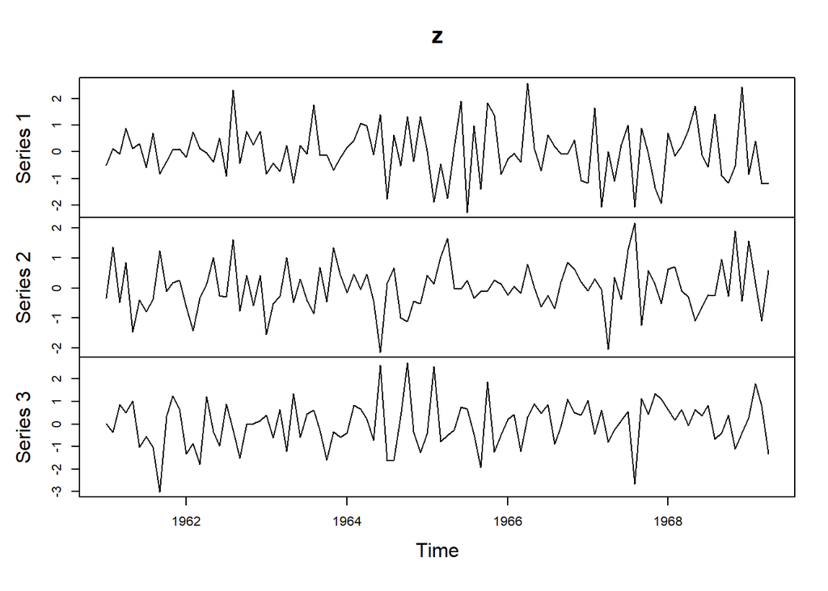

```r
plot(z)
```

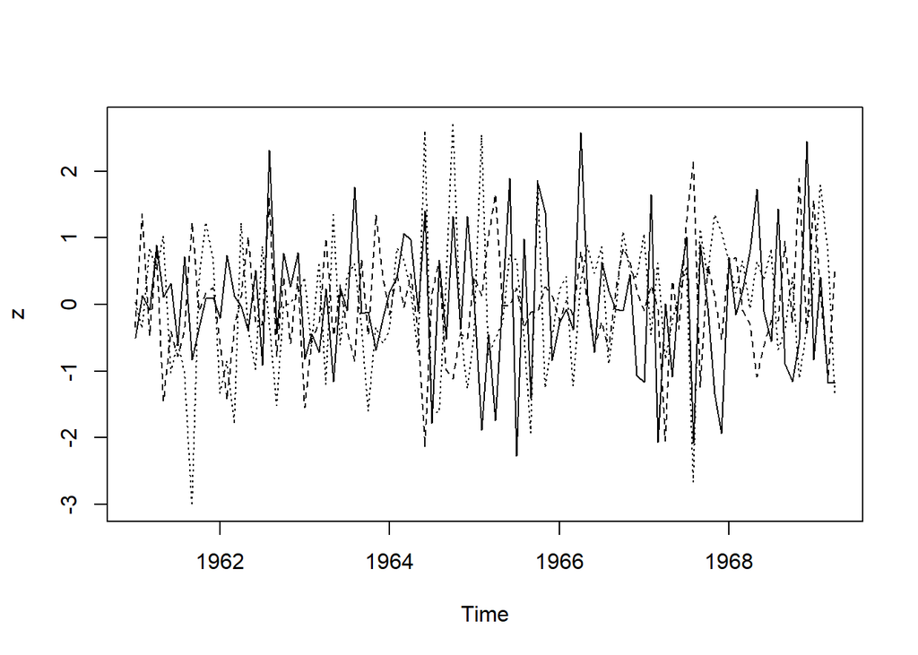

```r
plot(z, plot.type="single", lty=1:3)
```

### 01.4 R 객체 다루기

##### 01.4.1 객체 확인 및 전환하기

- 객체 확인하기  
  is.vector(), is.matrix(), is.data.frame(), is.table(), is.ts(), …
- 객체 전환하기 as.vector(), as.matrix(), as.data.frame(), as.table(), as.ts(), …

```r
a <- matrix(c(1:10), 2, 5)
is.data.frame(a)
```

```
## [1] FALSE
```

```r
is.matrix(a)
```

```
## [1] TRUE
```

```r
a %*% t(a)
```

```
##      [,1] [,2]
## [1,]  165  190
## [2,]  190  220
```

```r
b <- as.data.frame(a)
str(b)
```

```
## 'data.frame':    2 obs. of  5 variables:
##  $ V1: int  1 2
##  $ V2: int  3 4
##  $ V3: int  5 6
##  $ V4: int  7 8
##  $ V5: int  9 10
```

```r
#b %*% t(b)  # 객체 b는 행렬 객체가 아니므로 행렬연산(%*%) 수행 불가
as.matrix(b) %*% t(as.matrix(b))
```

```
##      [,1] [,2]
## [1,]  165  190
## [2,]  190  220
```

##### 01.4.2분석 결과객체 다루기

결과 객체에 저장된 정보의 종류(이름)는 names() 함수를 통해 확인할 수 있다.  
이와 유사한 함수로는 ls()와 objects()가 있다.

```r
## names() 함수의 적용 예
lm.iris <- lm(Sepal.Length ~ Sepal.Width, data=iris)  #lm.iris는 lm 객체임
names(lm.iris)  # lm 객체에 포함된 내용 확인
```

```
##  [1] "coefficients"  "residuals"     "effects"       "rank"
##  [5] "fitted.values" "assign"        "qr"            "df.residual"
##  [9] "xlevels"       "call"          "terms"         "model"
```

```r
ls(lm.iris)  # 제공되는 내용은 유사하나 순서가 다름 >> 알파벳 순서
```

```
##  [1] "assign"        "call"          "coefficients"  "df.residual"
##  [5] "effects"       "fitted.values" "model"         "qr"
##  [9] "rank"          "residuals"     "terms"         "xlevels"
```

```r
summary(lm.iris)  # lm 객체의 주요 결과 요약
```

```
##
## Call:
## lm(formula = Sepal.Length ~ Sepal.Width, data = iris)
##
## Residuals:
##    Min     1Q Median     3Q    Max
## -1.556 -0.633 -0.112  0.558  2.223
##
## Coefficients:
##             Estimate Std. Error t value Pr(>|t|)
## (Intercept)    6.526      0.479   13.63   <2e-16 ***
## Sepal.Width   -0.223      0.155   -1.44     0.15
## ---
## Signif. codes:  0 '***' 0.001 '**' 0.01 '*' 0.05 '.' 0.1 ' ' 1
##
## Residual standard error: 0.825 on 148 degrees of freedom
## Multiple R-squared:  0.0138, Adjusted R-squared:  0.00716
## F-statistic: 2.07 on 1 and 148 DF,  p-value: 0.152
```

names() 함수는 이름을 가진 객체의 이름(name)을 출력하거나 바꿀 때 사용하는 함수이다.

### 01.5 인덱싱과 벡터화 연산

##### 01.5.1 인덱싱

인덱싱(indexing)을 통해 벡터로부터 특정한 자료를 추출한다.  
[] 속의 인덱스 벡터는 논리형, 정수, 음의 정수, 문자열(:)이 가능하다.  
인덱싱은 벡터 객체 뿐만 아니라 행렬, 데이터프레임, 리스트 등의 객체에 대해서도 유사하게 적용된다.

```r
x <- c(-3, 5, 0, 50, 100, -10)
(y <- x >0)
```

```
## [1] FALSE  TRUE FALSE  TRUE  TRUE FALSE
```

```r
x[x > 0]  # x[y] 와 동일
```

```
## [1]   5  50 100
```

```r
x[x < -5 | x >= 50]  # | 은 or 연산자
```

```
## [1]  50 100 -10
```

```r
x[x > 0 & x < 100]  # & 은 and 연산자
```

```
## [1]  5 50
```

```r
x[-c(1, 3)]
```

```
## [1]   5  50 100 -10
```

```r
x[c(3:5)]
```

```
## [1]   0  50 100
```

##### 01.5.2 벡터화 연산

```r
v1 <- c(1, 2, 3, 4, 5)
2*v1  # 원소별로 연산이 적용됨
```

```
## [1]  2  4  6  8 10
```

```r
sqrt(v1)  # 원소별로 함수가 적용됨
```

```
## [1] 1.000 1.414 1.732 2.000 2.236
```

```r
1:10 * 10:1  # 대응되는 원소끼리 연산이 수행됨
```

```
##  [1] 10 18 24 28 30 30 28 24 18 10
```

```r
v2 <- c(10, 20, 30)
v1 + v2  # 벡터의 길이가 달라도 재순환 규칙(recycling rule)이 적용됨.
```

```
## [1] 11 22 33 14 25
```

### 01.6 R 함수 만들기와 프로그램 실행

##### 01.6.1 R 함수 만들기

R은 사용자가 분석에 필요한 함수를 만들어 사용할 수 있다.  
다음은 사용자 정의 함수의 간단한 예이다. - 가중평균을 구하는 함수 ( 함수명 : weighted.mean() )

```r
weighted.mean <- function(x, weighted=rep(1, length(x))) {
  sum(x * weighted) / sum(weighted)
}
weighted.mean(1:3)  # 함수 이용하기
```

```
## [1] 2
```

```r
weighted.mean(1:3, 3:1)
```

```
## [1] 1.667
```

함수는 한 개 또는 여러 개의 결과를 다양한 방식으로 제공할 수 있다.  
##### (a) 한 개의 결과 내보내기

```r
## 표준 오차 구하는 함수
std.error <- function(x) {
  v <- var(x)
  n <- length(x)
  se <- sqrt(v/n)
  return(se)  # return() 함수 : 한 개의 결과만 내보냄
}
# 위 함수는 다음과 동일함
std.error2 <- function(x) {
  v <- var(x)
  n <- length(x)
  sqrt(v/n)  #마지막 문장이 결과로 제공됨
}
std.error(c(1:10))
```

```
## [1] 0.9574
```

```r
std.error2(c(1:10))
```

```
## [1] 0.9574
```

##### (b) 여러 가지 결과를 리스트로 내보내기

```r
basic.stats <- function(x){
  n <- length(x)
  m <- mean(x)
  med <- median(x)
  s <- sd(x)
  list(n=n, mean=m, median=med, std=s)
  # list() 함수 : 여러 개의 결과를 내보냄
}
basic.stats(c(1:10))
```

```
## $n
## [1] 10
##
## $mean
## [1] 5.5
##
## $median
## [1] 5.5
##
## $std
## [1] 3.028
```

```r
## 위의 basis.stats() 함수는 다음과 같이 작성될 수 있음.
basic.stats2 <- function(x){
  stats <- list()  # 빈 리스트를 만듬
  stats$n <- length(x)
  stats$m <- mean(x)
  stats$med <- median(x)
  stats$s <- sd(x)
  stats  # 마지막 문장을 결과로 보냄
}
basic.stats2(c(1:10))
```

```
## $n
## [1] 10
##
## $m
## [1] 5.5
##
## $med
## [1] 5.5
##
## $s
## [1] 3.028
```

##### (c) 벡터 형태로 결과를 내보내기

```r
basic.stats <- function(x){
  n <- length(x)
  m <- mean(x)
  med <- median(x)
  s <- sd(x)
  out <- c(n, m, med, s)  # 벡터로 저장
  names(out) <- c("n","mean","median","std")  # 이름 부여
  round(out, 4)  # out을 출력하되 소수점 4자리까지만 출력력
}
basic.stats(c(1:10))
```

```
##      n   mean median    std
## 10.000  5.500  5.500  3.028
```

##### (d) R의 내장함수 수정하여 사용하기

R에서 제공되는 대부분의 함수는 그 소스가 제공되므로, 필요 시에는 목적에 맞게 수정하여 새로운 이름으로 저장하여 사용할 수 있다.  
이 경우 fix() 함수를 이용한다.

```r
fix(factorial)
```

##### ex1

자료에 대한 탐색적 분석을 수행하는 사용자 정의 함수를 하나 만들어 보자.( 함수명 : eda.shape() )

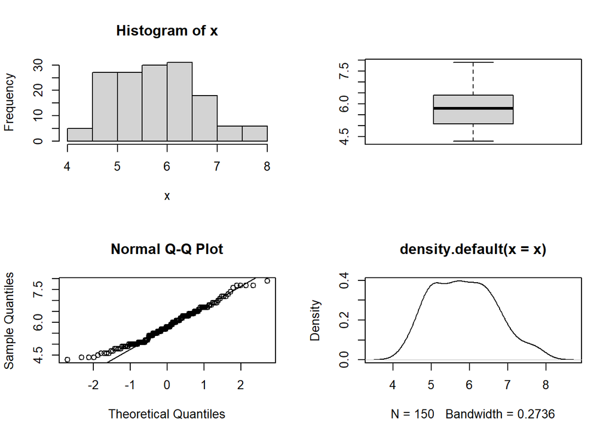

```r
eda.shape <- function(x) {
  par(mfrow=c(2,2))  # 그래픽을 2x2 행렬의 형태로 배치함
  # par() 함수는 전역적으로 그래픽 옵션을 지정하는 함수임
  hist(x)  # 첫 번째 그림
  boxplot(x)  # 두 번째 그림
  qqnorm(x)  # 세 번째 그림
  qqline(x)
  # qqline() 함수는 qqnorm() 함수의 실행 결과에 보조선을 추가하는 함수
  plot(density(x), type="l")  # 네 번째 그림
}

eda.shape(iris$Sepal.Length)
```